# Final Assignment

Importing data from original databse

```r
length(which(data$click_bool == 1))
```

```
[1] 221879
```

```r
mydata <- data[which(data$click_bool == 1),]
length(mydata)
```

```
[1] 19
```

loading and saving

```r
load(file = "../Data/mydata.RData")
# save(mydata,file = "../Data/mydata.RData")
mydata <- data
remove(data)
```

trim database

```r
mydata <- subset(mydata, select = -c(score) )
```

```
Error in eval(expr, envir, enclos) : object 'score' not found
```

subsetting

```r
mydata <- mydata[which(mydata$srch_id < 2000),]
# mydata <- head(mydata,1000)
length((unique(mydata$srch_id)))
```

```
[1] 1201
```

```r
median((unique(mydata$srch_id)))
```

```
[1] 1019
```

```r
max(mydata$srch_id)
```

```
[1] 1999
```

pairs plot

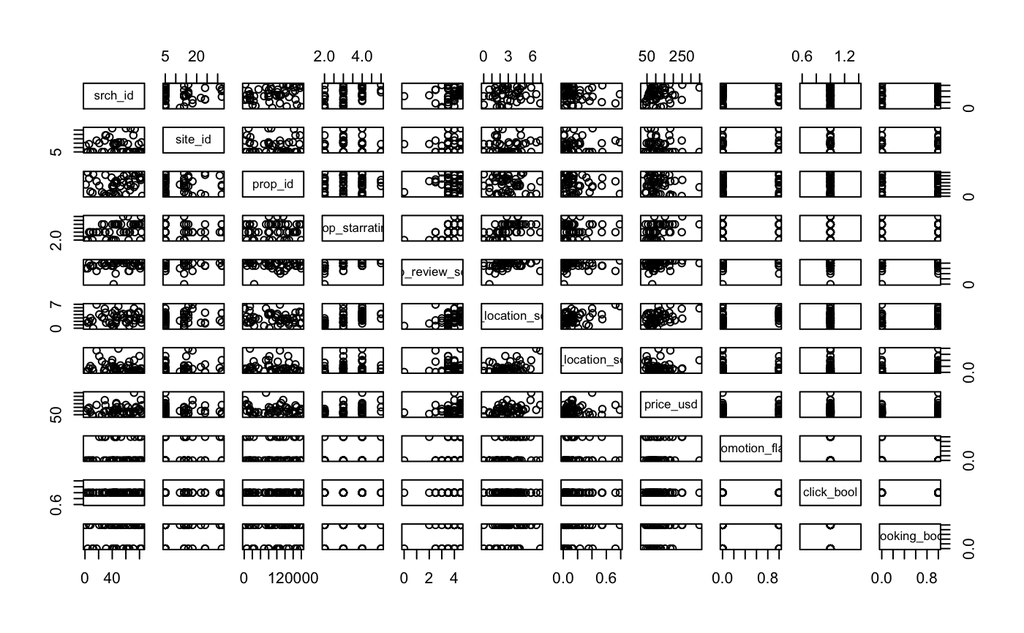

```r
df <- subset(head(mydata,50), select = -c(consumer))
pairs(df)
```

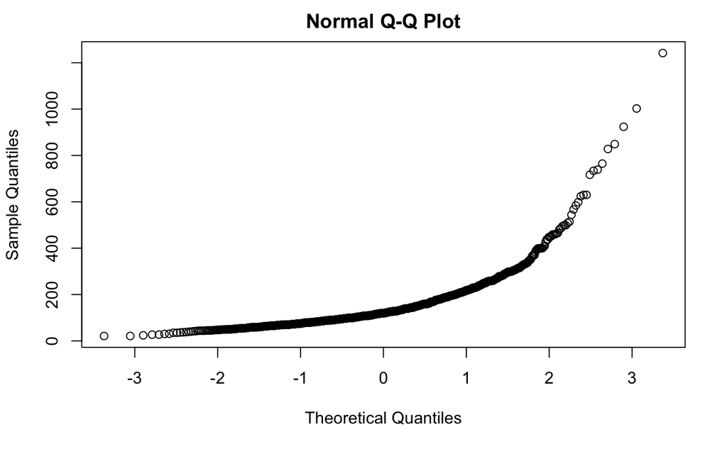

```r
qqnorm(mydata$price_usd)
```

```r
shapiro.test(mydata$price_usd)
```

```
    Shapiro-Wilk normality test

data:  mydata$price_usd
W = 0.71561, p-value < 2.2e-16
```

not normally disterbuted

```r
library(outliers)
chisq.out.test(mydata$price_usd, variance = var(mydata$price_usd),opposite = TRUE)
```

```
    chi-squared test for outlier

data:  mydata$price_usd
X-squared = 1.476, p-value = 0.2244
alternative hypothesis: lowest value 21 is an outlier
```

```r
chisq.out.test(mydata$price_usd, variance = var(mydata$price_usd),opposite = FALSE)
```

```
    chi-squared test for outlier

data:  mydata$price_usd
X-squared = 107.25, p-value < 2.2e-16
alternative hypothesis: highest value 1242 is an outlier
```

removing outliers

```r
mydata <- mydata[which(mydata$price_usd < 1242 ),]
chisq.out.test(mydata$price_usd, variance = var(mydata$price_usd),opposite = TRUE)
```

```
    chi-squared test for outlier

data:  mydata$price_usd
X-squared = 1.5839, p-value = 0.2082
alternative hypothesis: lowest value 21 is an outlier
```

```r
chisq.out.test(mydata$price_usd, variance = var(mydata$price_usd),opposite = FALSE)
```

```
    chi-squared test for outlier

data:  mydata$price_usd
X-squared = 71.271, p-value < 2.2e-16
alternative hypothesis: highest value 1002.82 is an outlier
```

```r
par(mfrow=c(3,2));
qqnorm(mydata$price_usd,main="price_usd")
qqnorm(mydata$prop_starrating,main="prop_starrating")
```

```r
qqnorm(mydata$prop_review_score,main="prop_review_score")
qqnorm(mydata$prop_location_score1,main="prop_location_score1")
```

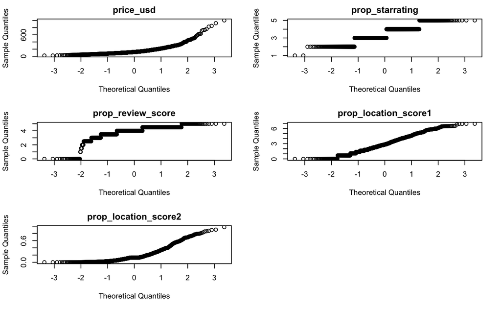

```r
qqnorm(mydata$prop_location_score2,main="prop_location_score2")
```

```r
par(mfrow=c(3,2));
hist(mydata$price_usd,main="price_usd")
hist(mydata$prop_starrating,main="prop_starrating")
```

```r
hist(mydata$prop_review_score,main="prop_review_score")
hist(mydata$prop_location_score1,main="prop_location_score1")
```

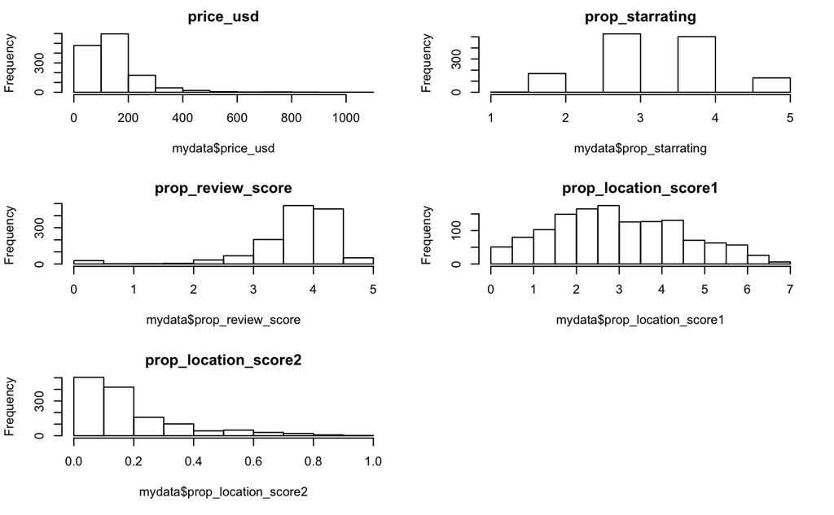

```r
hist(mydata$prop_location_score2,main="prop_location_score2")
```

```r
df <- subset(mydata, select = -c(consumer,click_bool,srch_id,site_id,prop_id))
round(cor(df),3)
```

```
                     prop_starrating prop_review_score prop_location_score1 prop_location_score2 price_usd promotion_flag
prop_starrating                1.000             0.301                0.271               -0.002     0.496          0.132
prop_review_score              0.301             1.000                0.130                0.036     0.231          0.054
prop_location_score1           0.271             0.130                1.000                0.292     0.267          0.139
prop_location_score2          -0.002             0.036                0.292                1.000     0.029          0.010
price_usd                      0.496             0.231                0.267                0.029     1.000         -0.028
promotion_flag                 0.132             0.054                0.139                0.010    -0.028          1.000
booking_bool                  -0.041             0.104               -0.022                0.076    -0.137          0.078
                     booking_bool
prop_starrating            -0.041
prop_review_score           0.104
prop_location_score1       -0.022
prop_location_score2        0.076
price_usd                  -0.137
promotion_flag              0.078
booking_bool                1.000
```

[output not shown]

randomized block design

```r
xtabs(price_usd ~ prop_starrating + consumer ,data=mydata)
```

```
               consumer
prop_starrating   couple    other  Parents   single
              1   187.94     0.00     0.00     0.00
              2  8067.63  2080.16  1333.20  3047.58
              3 38422.83  7036.91  3486.01 13276.20
              4 49440.41 10607.61  4740.32 17610.14
              5 22532.29  3813.11  2671.95  8985.97
```

```r
xtabs(price_usd ~ prop_starrating + prop_review_score ,data=mydata)
```

```
               prop_review_score
prop_starrating        0        1      1.5        2      2.5        3      3.5        4      4.5        5
              1     0.00     0.00     0.00     0.00     0.00     0.00   187.94     0.00     0.00     0.00
              2   735.24    94.00    60.00   258.17  1734.41  2169.48  3523.85  4016.64  1780.60   156.18
              3  1190.42    54.00   107.80   108.07   666.83  3366.38 11064.63 23780.05 19922.30  1961.47
              4  1297.61     0.00    96.14     0.00   219.01   778.44  6466.09 34094.84 35981.06  3465.29
              5   767.13     0.00     0.00     0.00     0.00   290.75   250.00  6812.40 22900.88  6982.16
```

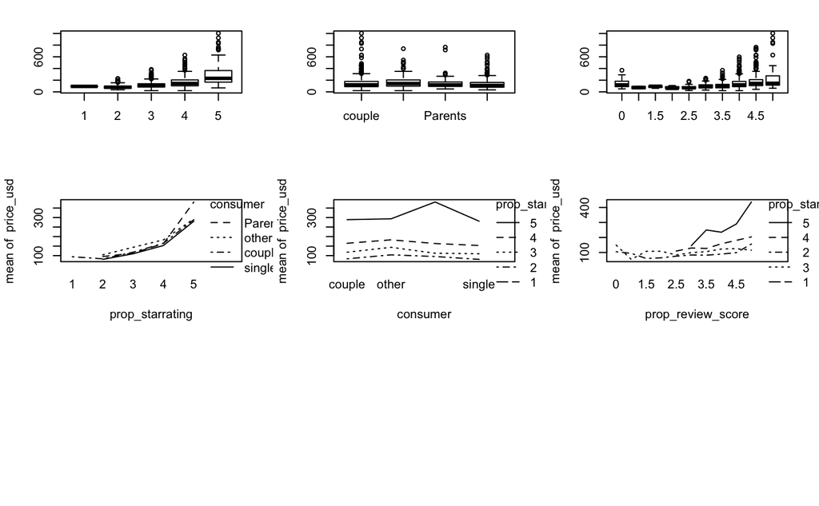

```r
attach(mydata)
par(mfrow=c(3,3))
boxplot(price_usd~prop_starrating); boxplot(price_usd~consumer) ; boxplot(price_usd~prop_review_score)
interaction.plot(prop_starrating,consumer,price_usd); interaction.plot(consumer,prop_starrating,price_usd) ; interaction.plot(prop_review_score,prop_starrating,price_usd)
```

```r
aovpen=lm(price_usd~prop_starrating+consumer,data=mydata)
anova(aovpen)
```

```
Analysis of Variance Table

Response: price_usd
                  Df   Sum Sq Mean Sq  F value Pr(>F)
prop_starrating    1  3355525 3355525 436.8567 <2e-16 ***
consumer           3    80892   26964   3.5104 0.0148 *
Residuals       1325 10177411    7681
---
Signif. codes:  0 ‘***’ 0.001 ‘**’ 0.01 ‘*’ 0.05 ‘.’ 0.1 ‘ ’ 1
```

```r
summary(aovpen)
```

```
Call:
lm(formula = price_usd ~ prop_starrating + consumer, data = mydata)

Residuals:
    Min      1Q  Median      3Q     Max
-179.63  -49.89  -12.29   29.49  761.78

Coefficients:
                Estimate Std. Error t value Pr(>|t|)
(Intercept)      -58.336     10.327  -5.649 1.97e-08 ***
prop_starrating   59.875      2.862  20.917  < 2e-16 ***
consumerother     19.466      8.027   2.425   0.0154 *
consumerParents    8.280     10.220   0.810   0.4180
consumersingle    -8.618      5.888  -1.464   0.1435
---
Signif. codes:  0 ‘***’ 0.001 ‘**’ 0.01 ‘*’ 0.05 ‘.’ 0.1 ‘ ’ 1

Residual standard error: 87.64 on 1325 degrees of freedom
Multiple R-squared:  0.2524,    Adjusted R-squared:  0.2502
F-statistic: 111.8 on 4 and 1325 DF,  p-value: < 2.2e-16
```

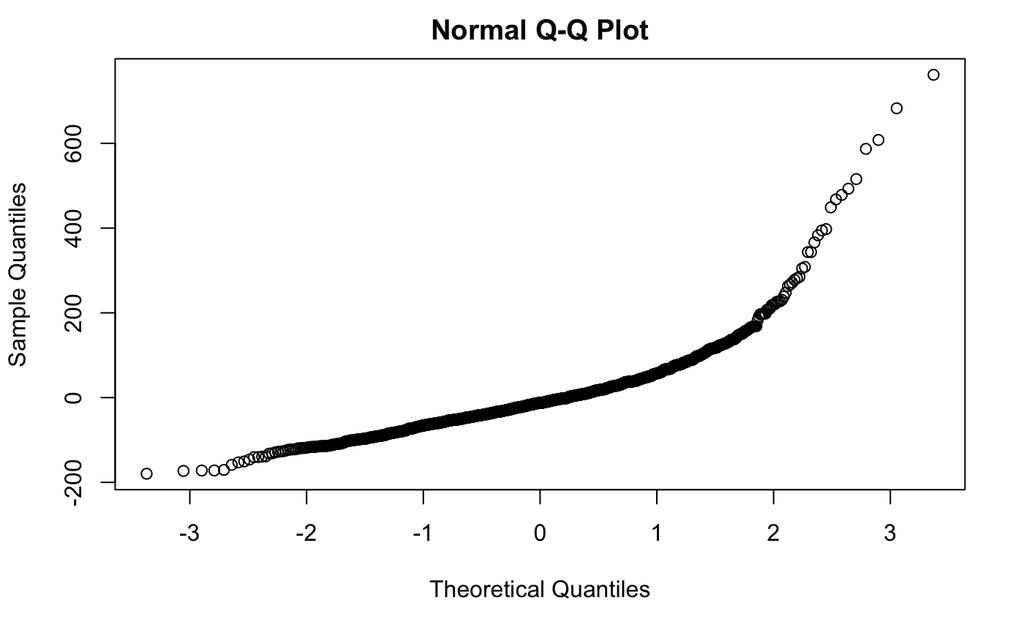

```r
qqnorm(residuals(aovpen))
```

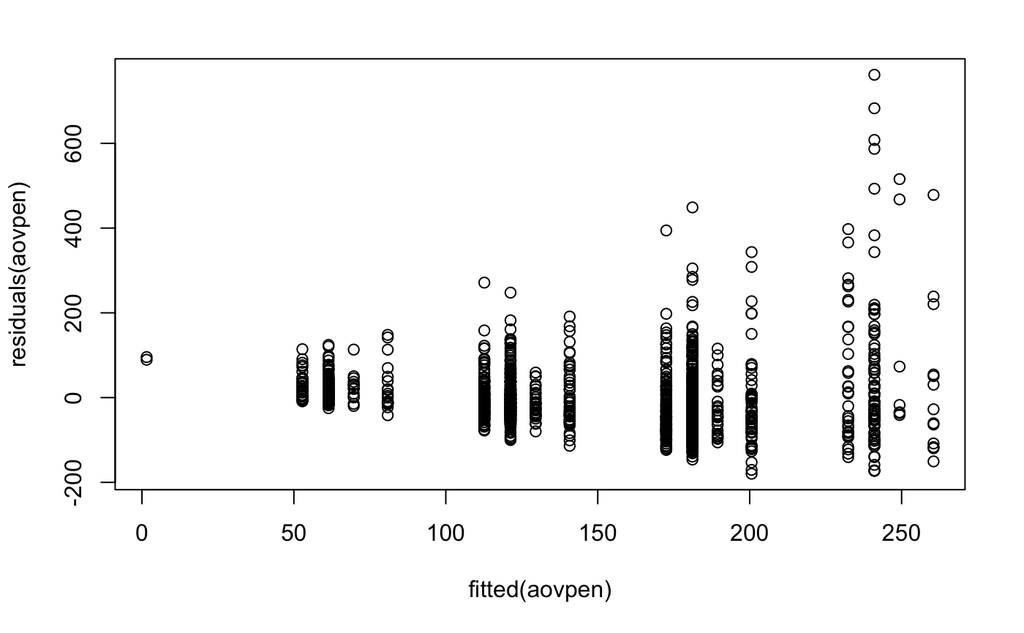

```r
plot(fitted(aovpen),residuals(aovpen))
```

```r
aovpen=lm(price_usd~prop_starrating+prop_review_score,data=mydata)
anova(aovpen)
```

```
Analysis of Variance Table

Response: price_usd
                    Df   Sum Sq Mean Sq F value    Pr(>F)
prop_starrating      1  3355525 3355525 438.315 < 2.2e-16 ***
prop_review_score    1    99433   99433  12.988  0.000325 ***
Residuals         1327 10158870    7656
---
Signif. codes:  0 ‘***’ 0.001 ‘**’ 0.01 ‘*’ 0.05 ‘.’ 0.1 ‘ ’ 1
```

```r
summary(aovpen)
```

```
Call:
lm(formula = price_usd ~ prop_starrating + prop_review_score,
    data = mydata)

Residuals:
    Min      1Q  Median      3Q     Max
-173.72  -49.62  -13.97   29.68  754.45

Coefficients:
                  Estimate Std. Error t value Pr(>|t|)
(Intercept)        -90.842     13.709  -6.626 4.99e-11 ***
prop_starrating     56.551      2.996  18.876  < 2e-16 ***
prop_review_score   11.291      3.133   3.604 0.000325 ***
---
Signif. codes:  0 ‘***’ 0.001 ‘**’ 0.01 ‘*’ 0.05 ‘.’ 0.1 ‘ ’ 1

Residual standard error: 87.5 on 1327 degrees of freedom
Multiple R-squared:  0.2538,    Adjusted R-squared:  0.2527
F-statistic: 225.7 on 2 and 1327 DF,  p-value: < 2.2e-16
```

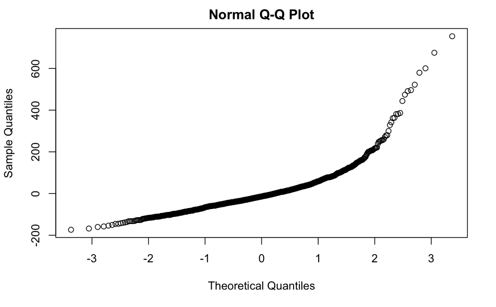

```r
qqnorm(residuals(aovpen))
```

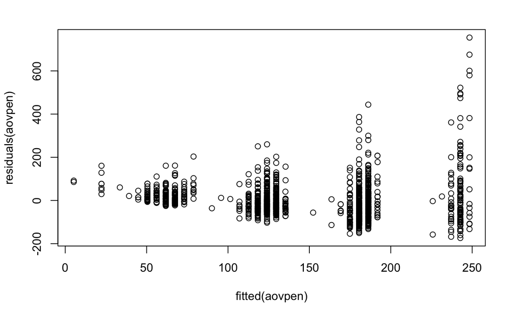

```r
plot(fitted(aovpen),residuals(aovpen))
```

prop_starrating is more significant than consumer type and prop_review_score but also both significant

```r
aovpen=lm(price_usd~prop_review_score + consumer,data=mydata)
anova(aovpen)
```

```
Analysis of Variance Table

Response: price_usd
                    Df   Sum Sq Mean Sq F value  Pr(>F)
prop_review_score    1   727322  727322 75.2239 < 2e-16 ***
consumer             3    75400   25133  2.5994 0.05082 .
Residuals         1325 12811107    9669
---
Signif. codes:  0 ‘***’ 0.001 ‘**’ 0.01 ‘*’ 0.05 ‘.’ 0.1 ‘ ’ 1
```

```r
summary(aovpen)
```

```
Call:
lm(formula = price_usd ~ prop_review_score + consumer, data = mydata)

Residuals:
    Min      1Q  Median      3Q     Max
-139.79  -58.46  -28.48   27.24  824.43

Coefficients:
                  Estimate Std. Error t value Pr(>|t|)
(Intercept)         32.833     13.700   2.397   0.0167 *
prop_review_score   29.112      3.357   8.672   <2e-16 ***
consumerother       20.508      9.006   2.277   0.0229 *
consumerParents      4.060     11.464   0.354   0.7233
consumersingle      -7.214      6.606  -1.092   0.2750
---
Signif. codes:  0 ‘***’ 0.001 ‘**’ 0.01 ‘*’ 0.05 ‘.’ 0.1 ‘ ’ 1

Residual standard error: 98.33 on 1325 degrees of freedom
Multiple R-squared:  0.05896,   Adjusted R-squared:  0.05612
F-statistic: 20.76 on 4 and 1325 DF,  p-value: < 2.2e-16
```

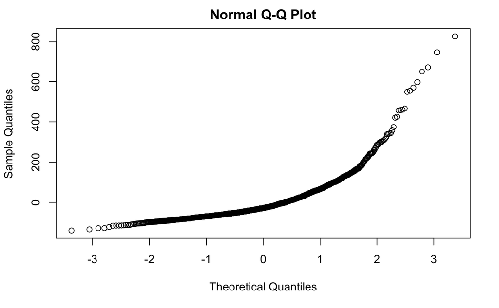

```r
qqnorm(residuals(aovpen))
```

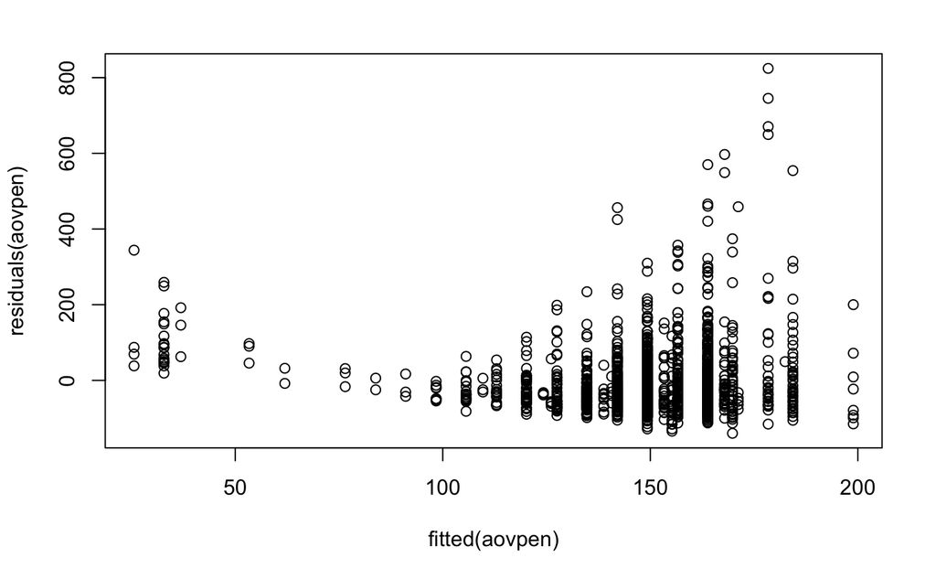

```r
plot(fitted(aovpen),residuals(aovpen))
```

# Logistic Regression

An experiment with: an outcome Y that is 0 or 1 (“binary dependent variable”); one or more numerical explanatory variables X1,…,Xp. one or more factor explanatory variables. (“independent variable”). The purpose is to explain Y by a function of X.

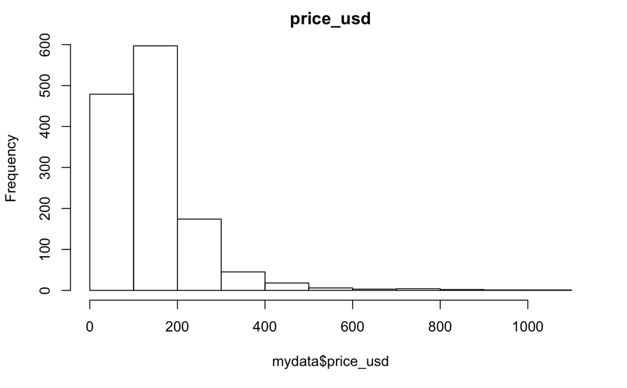

```r
tot=xtabs(~prop_review_score+price_usd,data=mydata);
hist(mydata$price_usd,main="price_usd");
```

```r
round(xtabs(booking_bool~prop_review_score+price_usd,data=mydata)/tot,2)
```

[output not shown]

[output cut: 75 more lines]

[output not shown]

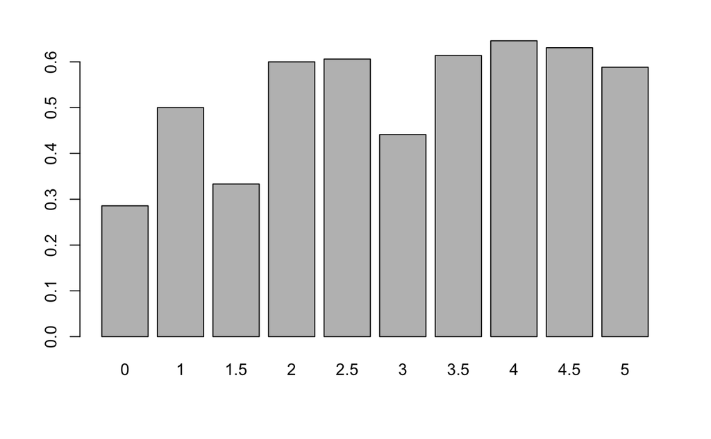

```r
totage=xtabs(~prop_review_score,data=mydata)
barplot(xtabs(booking_bool~prop_review_score,data=esoph)/totage)
```

```r
mydata$prop_review_score2 <- mydata$prop_review_score^2
myglm=glm(booking_bool~prop_review_score+prop_review_score2+price_usd,data=mydata,family=binomial)
summary(myglm)
```

```
Call:
glm(formula = booking_bool ~ prop_review_score + prop_review_score2 +
    price_usd, family = binomial, data = mydata)

Deviance Residuals:
    Min       1Q   Median       3Q      Max
-1.6152  -1.3347   0.8617   0.9569   1.8109

Coefficients:
                     Estimate Std. Error z value Pr(>|z|)
(Intercept)        -0.4842368  0.4171012  -1.161    0.246
prop_review_score   0.3766191  0.2553104   1.475    0.140
prop_review_score2 -0.0001990  0.0428112  -0.005    0.996
price_usd          -0.0035606  0.0006433  -5.535 3.11e-08 ***
---
Signif. codes:  0 ‘***’ 0.001 ‘**’ 0.01 ‘*’ 0.05 ‘.’ 0.1 ‘ ’ 1

(Dispersion parameter for binomial family taken to be 1)

    Null deviance: 1774.6  on 1329  degrees of freedom
Residual deviance: 1723.9  on 1326  degrees of freedom
AIC: 1731.9

Number of Fisher Scoring iterations: 4
```